# Ujjawal_Singh_Nirwan_ML_A3

### 1. Problem Statement:

- The problem states that 30% of the candidates who accept the job offer do not join the company. HRWorks wants to find if a model can be built to predict the likelihood of a candidate joining the company.
- Now we have to compare all the factors that tell us that what factors are affecting for a candidate so that they are not joining the company.
- We have to also relate these factors to understand whether a candidate will join or not based on the given circumstances in future.

### Why it is needed:

- As we know taking interviews and exams of applied candidates includes some kind of resources and time which may lead to loss if a candidate doesn't join after clearing all the stages.
- Because of this sometime we loose a candidate who is willing to work but scored less in eligibility criteria.
- Sometimes we loose a good or best candidate or we can say desired candidate that will help to increase the future of the company ot will increase the revenue of the company in some way. So we want to understand what the problem they are facing in joing the company.

```python
%matplotlib inline
import pandas as pd
import numpy as np
import matplotlib.pyplot as plt
import seaborn as sns
import warnings
import sklearn
import statsmodels.api as sm
import scipy.stats as st
from sklearn import preprocessing
from sklearn.model_selection import train_test_split
from sklearn import metrics
from sklearn.impute import SimpleImputer
from sklearn.metrics import mean_squared_error
from sklearn.model_selection import cross_val_score, train_test_split
from sklearn.ensemble import RandomForestRegressor
from sklearn.linear_model import LogisticRegression
from sklearn.tree import DecisionTreeClassifier
from sklearn.neighbors import KNeighborsClassifier
from sklearn.metrics import classification_report
from sklearn.metrics import mean_squared_error
from sklearn.preprocessing import StandardScaler
from sklearn.model_selection import GridSearchCV
warnings.filterwarnings('ignore')
sns.set()
```

```python
data=pd.read_csv("hr_data.csv")
data.head()
```

|  | SLNO | Candidate Ref | DOJ Extended | Duration to accept offer | Notice period | Offered band | Pecent hike expected in CTC | Percent hike offered in CTC | Percent difference CTC | Joining Bonus | Candidate relocate actual | Gender | Candidate Source | Rex in Yrs | LOB | Location | Age | Status |
| --- | --- | --- | --- | --- | --- | --- | --- | --- | --- | --- | --- | --- | --- | --- | --- | --- | --- | --- |
| 0 | 1 | 2110407 | Yes | 14 | 30 | E2 | -20.79 | 13.16 | 42.86 | No | No | Female | Agency | 7 | ERS | Noida | 34.0 | Joined |
| 1 | 2 | 2112635 | No | 18 | 30 | E2 | 50.00 | 320.00 | 180.00 | No | No | Male | Employee Referral | 8 | INFRA | Chennai | 34.0 | Joined |
| 2 | 3 | 2112838 | No | 3 | 45 | E2 | 42.84 | 42.84 | 0.00 | No | No | Male | Agency | 4 | INFRA | Noida | 27.0 | Joined |
| 3 | 4 | 2115021 | No | 26 | 30 | E2 | 42.84 | 42.84 | 0.00 | No | No | Male | Employee Referral | 4 | INFRA | Noida | 34.0 | Joined |
| 4 | 5 | 2115125 | Yes | 1 | 120 | E2 | 42.59 | 42.59 | 0.00 | No | Yes | Male | Employee Referral | 6 | INFRA | Noida | 34.0 | Joined |

```python
data.shape
```

```
(8995, 18)
```

```python
data.describe().T
```

|  | count | mean | std | min | 25% | 50% | 75% | max |
| --- | --- | --- | --- | --- | --- | --- | --- | --- |
| SLNO | 8995.0 | 5.970984e+03 | 3373.963454 | 1.00 | 3207.50 | 5976.0 | 8739.00 | 12333.00 |
| Candidate Ref | 8995.0 | 2.843647e+06 | 486344.774552 | 2109586.00 | 2386476.00 | 2807482.0 | 3300059.50 | 3836076.00 |
| Duration to accept offer | 8995.0 | 2.143446e+01 | 25.811616 | 0.00 | 3.00 | 10.0 | 33.00 | 224.00 |
| Notice period | 8995.0 | 3.929183e+01 | 22.220239 | 0.00 | 30.00 | 30.0 | 60.00 | 120.00 |
| Pecent hike expected in CTC | 8995.0 | 4.386480e+01 | 29.788975 | -68.83 | 27.27 | 40.0 | 53.85 | 359.77 |
| Percent hike offered in CTC | 8995.0 | 4.065736e+01 | 36.064060 | -60.53 | 22.09 | 36.0 | 50.00 | 471.43 |
| Percent difference CTC | 8995.0 | -1.573802e+00 | 19.610729 | -67.27 | -8.33 | 0.0 | 0.00 | 300.00 |
| Rex in Yrs | 8995.0 | 4.239022e+00 | 2.547571 | 0.00 | 3.00 | 4.0 | 6.00 | 24.00 |
| Age | 8980.0 | 2.991203e+01 | 4.095699 | 20.00 | 27.00 | 29.0 | 34.00 | 60.00 |

As we can see that there are outliers present in Are which are needed in the analysis

```python
data.describe(include=object).T
```

|  | count | unique | top | freq |
| --- | --- | --- | --- | --- |
| DOJ Extended | 8995 | 2 | No | 4788 |
| Offered band | 8982 | 4 | E1 | 5565 |
| Joining Bonus | 8995 | 2 | No | 8578 |
| Candidate relocate actual | 8995 | 2 | No | 7705 |
| Gender | 8995 | 2 | Male | 7444 |
| Candidate Source | 8995 | 3 | Direct | 4801 |
| LOB | 8995 | 9 | INFRA | 2850 |
| Location | 8995 | 11 | Chennai | 3150 |
| Status | 8995 | 2 | Joined | 7313 |

```python
data.info()
```

```
<class 'pandas.core.frame.DataFrame'>
RangeIndex: 8995 entries, 0 to 8994
Data columns (total 18 columns):
 #   Column                       Non-Null Count  Dtype
---  ------                       --------------  -----
 0   SLNO                         8995 non-null   int64
 1   Candidate Ref                8995 non-null   int64
 2   DOJ Extended                 8995 non-null   object
 3   Duration to accept offer     8995 non-null   int64
 4   Notice period                8995 non-null   int64
 5   Offered band                 8982 non-null   object
 6   Pecent hike expected in CTC  8995 non-null   float64
 7   Percent hike offered in CTC  8995 non-null   float64
 8   Percent difference CTC       8995 non-null   float64
 9   Joining Bonus                8995 non-null   object
 10  Candidate relocate actual    8995 non-null   object
 11  Gender                       8995 non-null   object
 12  Candidate Source             8995 non-null   object
 13  Rex in Yrs                   8995 non-null   int64
 14  LOB                          8995 non-null   object
 15  Location                     8995 non-null   object
 16  Age                          8980 non-null   float64
 17  Status                       8995 non-null   object
dtypes: float64(4), int64(5), object(9)
memory usage: 1.2+ MB
```

```python
data.columns
```

```
Index(['SLNO', 'Candidate Ref', 'DOJ Extended', 'Duration to accept offer',
       'Notice period', 'Offered band', 'Pecent hike expected in CTC',
       'Percent hike offered in CTC', 'Percent difference CTC',
       'Joining Bonus', 'Candidate relocate actual', 'Gender',
       'Candidate Source', 'Rex in Yrs', 'LOB', 'Location', 'Age', 'Status'],
      dtype='object')
```

```python
data.isnull().sum()
```

```
SLNO                            0
Candidate Ref                   0
DOJ Extended                    0
Duration to accept offer        0
Notice period                   0
Offered band                   13
Pecent hike expected in CTC     0
Percent hike offered in CTC     0
Percent difference CTC          0
Joining Bonus                   0
Candidate relocate actual       0
Gender                          0
Candidate Source                0
Rex in Yrs                      0
LOB                             0
Location                        0
Age                            15
Status                          0
dtype: int64
```

```python
data.duplicated().sum()
```

```
0
```

```python
data.dropna()
```

|  | SLNO | Candidate Ref | DOJ Extended | Duration to accept offer | Notice period | Offered band | Pecent hike expected in CTC | Percent hike offered in CTC | Percent difference CTC | Joining Bonus | Candidate relocate actual | Gender | Candidate Source | Rex in Yrs | LOB | Location | Age | Status |
| --- | --- | --- | --- | --- | --- | --- | --- | --- | --- | --- | --- | --- | --- | --- | --- | --- | --- | --- |
| 0 | 1 | 2110407 | Yes | 14 | 30 | E2 | -20.79 | 13.16 | 42.86 | No | No | Female | Agency | 7 | ERS | Noida | 34.0 | Joined |
| 1 | 2 | 2112635 | No | 18 | 30 | E2 | 50.00 | 320.00 | 180.00 | No | No | Male | Employee Referral | 8 | INFRA | Chennai | 34.0 | Joined |
| 2 | 3 | 2112838 | No | 3 | 45 | E2 | 42.84 | 42.84 | 0.00 | No | No | Male | Agency | 4 | INFRA | Noida | 27.0 | Joined |
| 3 | 4 | 2115021 | No | 26 | 30 | E2 | 42.84 | 42.84 | 0.00 | No | No | Male | Employee Referral | 4 | INFRA | Noida | 34.0 | Joined |
| 4 | 5 | 2115125 | Yes | 1 | 120 | E2 | 42.59 | 42.59 | 0.00 | No | Yes | Male | Employee Referral | 6 | INFRA | Noida | 34.0 | Joined |
| ... | ... | ... | ... | ... | ... | ... | ... | ... | ... | ... | ... | ... | ... | ... | ... | ... | ... | ... |
| 8990 | 12319 | 3822427 | No | 4 | 0 | E1 | 191.67 | 191.67 | 0.00 | No | No | Male | Employee Referral | 1 | ERS | Chennai | 34.0 | Joined |
| 8991 | 12327 | 3828206 | Yes | 2 | 0 | E1 | 150.00 | 150.00 | 0.00 | No | No | Female | Direct | 3 | BFSI | Chennai | 34.0 | Joined |
| 8992 | 12331 | 3834159 | No | 0 | 0 | E2 | 35.42 | 35.42 | 0.00 | No | No | Male | Direct | 5 | INFRA | Noida | 34.0 | Joined |
| 8993 | 12332 | 3835433 | No | 0 | 30 | E1 | 76.92 | 53.85 | -13.04 | No | No | Male | Direct | 4 | INFRA | Noida | 34.0 | Joined |
| 8994 | 12333 | 3836076 | No | 2 | 0 | E1 | 45.25 | 14.09 | -21.45 | No | No | Female | Employee Referral | 1 | INFRA | Chennai | 34.0 | Joined |

8968 rows × 18 columns

## Treating missing values

As age contains outliers we will use **Median** instead of **Mean**

```python
data['Age'].fillna(data["Age"].median(),inplace=True)
```

```python
data['Offered band'].value_counts()
```

```
E1    5565
E2    2704
E3     502
E0     211
Name: Offered band, dtype: int64
```

```python
imputer=data.copy()
```

```python
freq_imputer=SimpleImputer(strategy='most_frequent')
```

```python
imputer.loc[:,['Offered band']]=freq_imputer.fit_transform(imputer.loc[:,['Offered band']])
```

```python
data=imputer.copy()
```

```python
data.isnull().sum()
```

```
SLNO                           0
Candidate Ref                  0
DOJ Extended                   0
Duration to accept offer       0
Notice period                  0
Offered band                   0
Pecent hike expected in CTC    0
Percent hike offered in CTC    0
Percent difference CTC         0
Joining Bonus                  0
Candidate relocate actual      0
Gender                         0
Candidate Source               0
Rex in Yrs                     0
LOB                            0
Location                       0
Age                            0
Status                         0
dtype: int64
```

### 2. Hypothesis:

- H<sub>0</sub>: Based on the given information by a candidate will join
- H<sub>1</sub>: Based on the given information by a candidate will not join

### 3. Data Exploration

```python
data.columns
```

```
Index(['SLNO', 'Candidate Ref', 'DOJ Extended', 'Duration to accept offer',
       'Notice period', 'Offered band', 'Pecent hike expected in CTC',
       'Percent hike offered in CTC', 'Percent difference CTC',
       'Joining Bonus', 'Candidate relocate actual', 'Gender',
       'Candidate Source', 'Rex in Yrs', 'LOB', 'Location', 'Age', 'Status'],
      dtype='object')
```

```python
data['Status'].value_counts()
```

```
Joined        7313
Not Joined    1682
Name: Status, dtype: int64
```

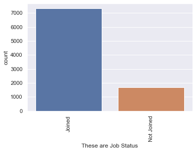

```python
sns.countplot(data['Status'])
plt.xticks(rotation=90)
plt.xlabel('These are Job Status');
```

Most of the candidate have joined

```python
def countp(x, data):
    plt.figure(figsize = (10,8))
    sns.countplot(x = x, data = data, hue = 'Status', palette = 'rocket')
    plt.xlabel(x)
    plt.xticks(rotation=90)
```

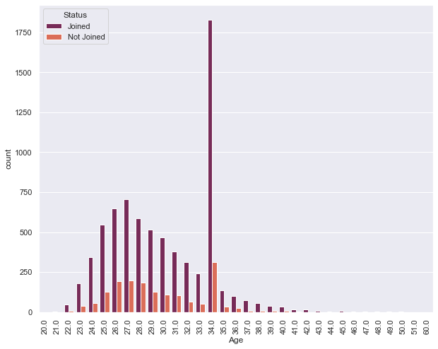

```python
countp('Age',data)
```

We can see that people falling under 34 years age are most joined and not joined

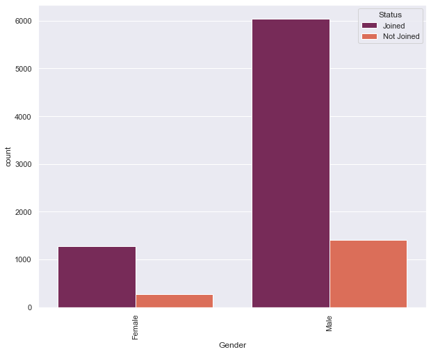

```python
countp('Gender',data)
```

Males are most joined and not joined among genders

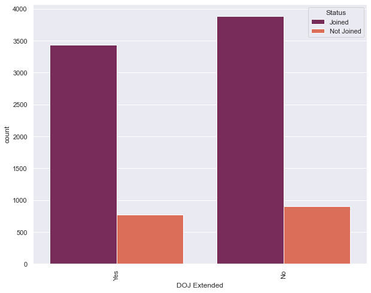

```python
countp('DOJ Extended',data)
```

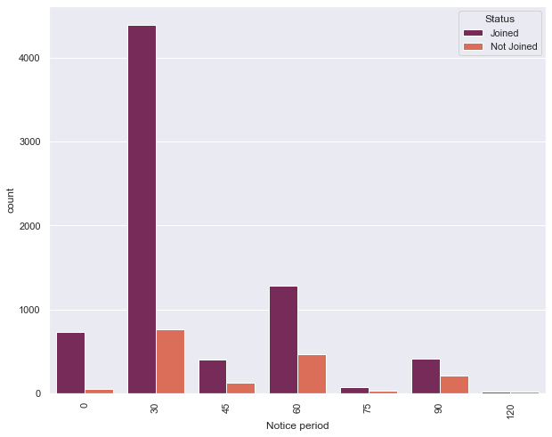

```python
countp('Notice period',data)
```

Those who got a notice period of 30 days joined and not joined more

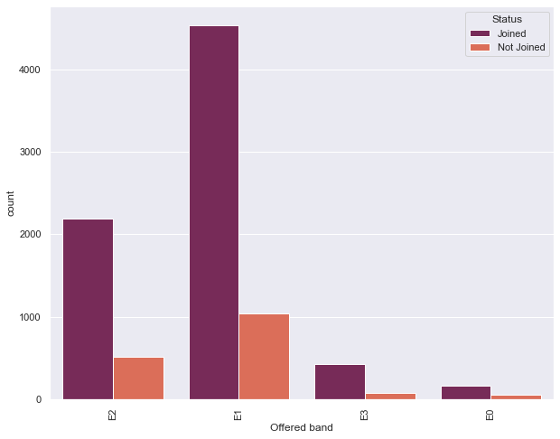

```python
countp('Offered band',data)
```

Most of the people joined and not joined E1 Offered band

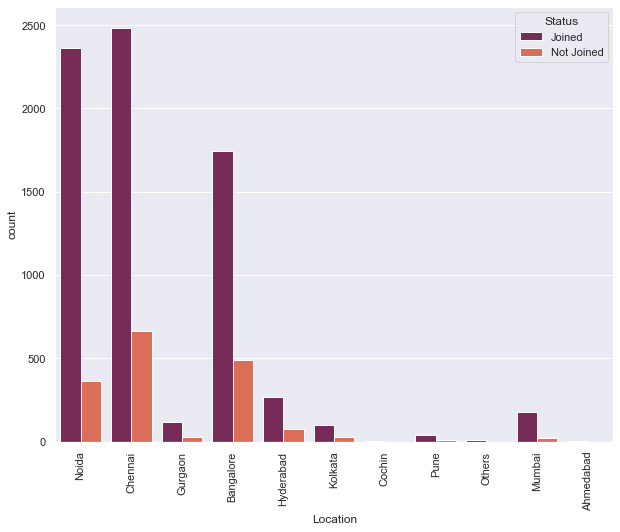

```python
countp('Location',data)
```

Most of the people joined are from Chennai and Noida while not joined are Chennai and Banglore

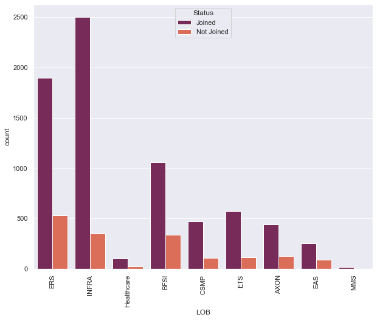

```python
countp('LOB',data)
```

MOst of the people joined in INFRA and ERS Line of Bussiness while not joined in ERS, INFRA and BFSi

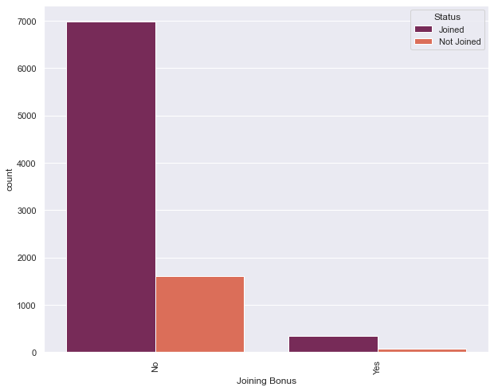

```python
countp('Joining Bonus',data)
```

Those who didn't got any joining bonus are most who joined or not joined

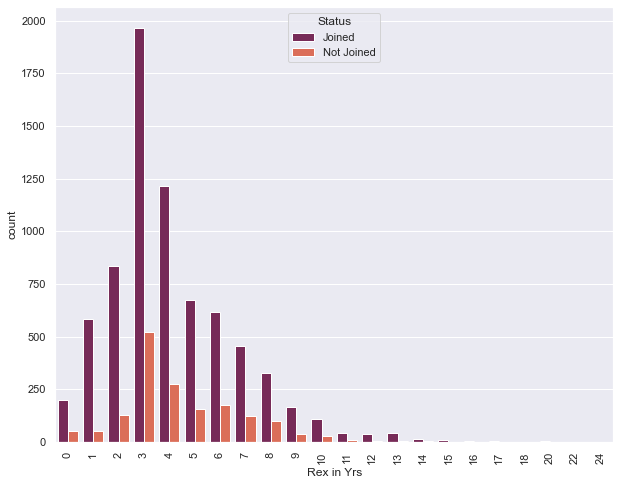

```python
countp('Rex in Yrs',data)
```

Those who got age relaxation between 3 to 4 yrs joined and not joined more

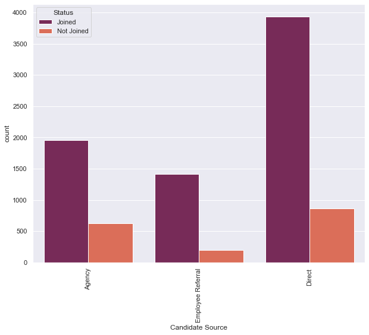

```python
countp('Candidate Source',data)
```

Those who came direct are the most joined and not joined while those who are refered by company are least joined and not joined

### Treatment of outliers

Removing Outliers from Age

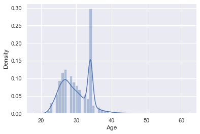

```python
sns.distplot(data['Age']);
```

```python
data=data[data['Age'] < data['Age'].quantile(.99)]
```

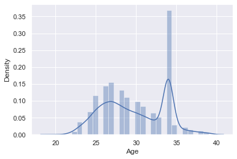

```python
sns.distplot(data['Age']);
```

Removing Outliers from Pecent hike expected in CT

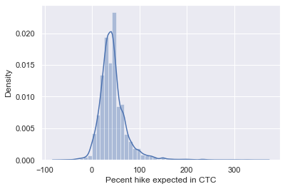

```python
sns.distplot(data['Pecent hike expected in CTC']);
```

```python
data=data[data['Pecent hike expected in CTC'] < data['Pecent hike expected in CTC'].quantile(.99)]
```

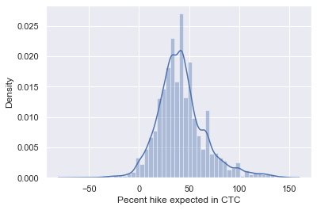

```python
sns.distplot(data['Pecent hike expected in CTC']);
```

Removing Outliers from Percent hike offered in CTC

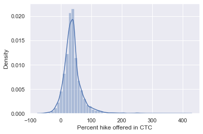

```python
sns.distplot(data['Percent hike offered in CTC']);
```

```python
data=data[data['Percent hike offered in CTC'] < data['Percent hike offered in CTC'].quantile(.99)]
```

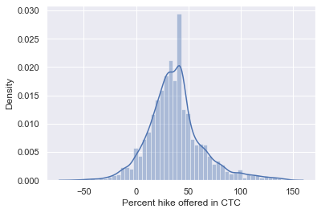

```python
sns.distplot(data['Percent hike offered in CTC']);
```

Removing Outliers from Percent difference CTC

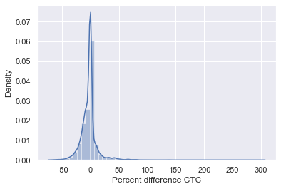

```python
sns.distplot(data['Percent difference CTC']);
```

```python
data=data[data['Percent difference CTC'] < data['Percent difference CTC'].quantile(.99)]
```

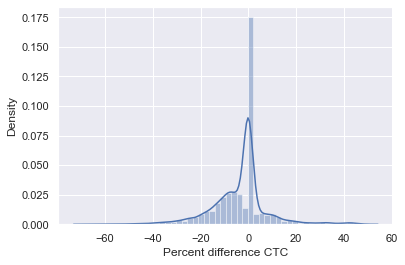

```python
sns.distplot(data['Percent difference CTC']);
```

Removing Outliers from Rex in Yrs

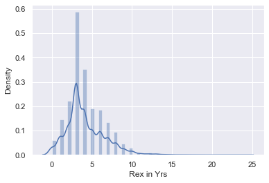

```python
sns.distplot(data['Rex in Yrs']);
```

```python
data=data[data['Rex in Yrs'] < data['Rex in Yrs'].quantile(.99)]
```

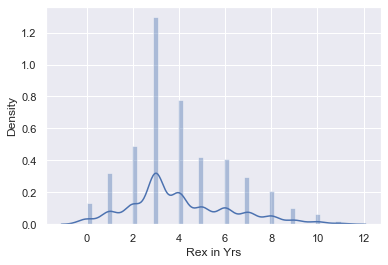

```python
sns.distplot(data['Rex in Yrs']);
```

## 4. Model

### Logistic Regression

```python
data['Status']=data['Status'].apply(lambda x:0 if x=='Not Joined' else 1)
```

```python
x_feature = list(data.columns)
x_feature.remove('Status')
x_feature.remove("Pecent hike expected in CTC")
x_feature.remove("Percent hike offered in CTC")
x_feature.remove("SLNO")
x_feature.remove("Candidate Ref")
```

```python
encoded_data = pd.get_dummies(data[x_feature],drop_first=True)
```

```python
y = data['Status']
x1 = encoded_data
x = sm.add_constant(x1)
```

```python
x_train,x_test,y_train,y_test = train_test_split(x,y, train_size = 0.8, random_state = 42)
```

```python
logit = sm.Logit(y_train, x_train)
```

```python
logit=logit.fit(method='bfgs')
```

```python
logit.summary2()
```

| Model: | Logit | Pseudo R-squared: | 0.139 |
| --- | --- | --- | --- |
| Dependent Variable: | Status | AIC: | 5783.0962 |
| Date: | 2021-06-26 23:33 | BIC: | 6008.2717 |
| No. Observations: | 6792 | Log-Likelihood: | -2858.5 |
| Df Model: | 32 | LL-Null: | -3319.1 |
| Df Residuals: | 6759 | LLR p-value: | 7.0093e-173 |
| Converged: | 0.0000 | Scale: | 1.0000 |

|  | Coef. | Std.Err. | z | P>\|z\| | [0.025 | 0.975] |
| --- | --- | --- | --- | --- | --- | --- |
| const | 0.1594 | 1.7713 | 0.0900 | 0.9283 | -3.3122 | 3.6310 |
| Duration to accept offer | 0.0009 | 0.0014 | 0.6806 | 0.4961 | -0.0017 | 0.0036 |
| Notice period | -0.0215 | 0.0016 | -13.5207 | 0.0000 | -0.0247 | -0.0184 |
| Percent difference CTC | 0.0072 | 0.0029 | 2.4784 | 0.0132 | 0.0015 | 0.0128 |
| Rex in Yrs | -0.0113 | 0.0261 | -0.4324 | 0.6654 | -0.0625 | 0.0399 |
| Age | 0.0339 | 0.0111 | 3.0451 | 0.0023 | 0.0121 | 0.0557 |
| DOJ Extended_Yes | 0.2204 | 0.0735 | 3.0004 | 0.0027 | 0.0764 | 0.3644 |
| Offered band_E1 | 0.5486 | 0.2309 | 2.3760 | 0.0175 | 0.0961 | 1.0011 |
| Offered band_E2 | 0.4597 | 0.2574 | 1.7860 | 0.0741 | -0.0448 | 0.9642 |
| Offered band_E3 | 0.3041 | 0.3265 | 0.9313 | 0.3517 | -0.3359 | 0.9441 |
| Joining Bonus_Yes | -0.2322 | 0.1601 | -1.4506 | 0.1469 | -0.5460 | 0.0815 |
| Candidate relocate actual_Yes | 4.3766 | 0.5201 | 8.4151 | 0.0000 | 3.3573 | 5.3960 |
| Gender_Male | -0.1376 | 0.0888 | -1.5506 | 0.1210 | -0.3116 | 0.0363 |
| Candidate Source_Direct | 0.3090 | 0.0760 | 4.0670 | 0.0000 | 0.1601 | 0.4579 |
| Candidate Source_Employee Referral | 0.7430 | 0.1126 | 6.5993 | 0.0000 | 0.5224 | 0.9637 |
| LOB_BFSI | 0.3537 | 0.1593 | 2.2206 | 0.0264 | 0.0415 | 0.6658 |
| LOB_CSMP | 0.1908 | 0.1816 | 1.0506 | 0.2935 | -0.1652 | 0.5468 |
| LOB_EAS | -0.5525 | 0.2008 | -2.7515 | 0.0059 | -0.9460 | -0.1589 |
| LOB_ERS | 0.2164 | 0.1509 | 1.4341 | 0.1515 | -0.0794 | 0.5122 |
| LOB_ETS | 0.5578 | 0.1809 | 3.0834 | 0.0020 | 0.2032 | 0.9124 |
| LOB_Healthcare | 0.1335 | 0.2808 | 0.4754 | 0.6345 | -0.4169 | 0.6839 |
| LOB_INFRA | 0.6882 | 0.1654 | 4.1598 | 0.0000 | 0.3640 | 1.0125 |
| LOB_MMS | 0.1594 | 0.7646 | 0.2085 | 0.8348 | -1.3391 | 1.6579 |
| Location_Bangalore | -0.0890 | 1.7271 | -0.0515 | 0.9589 | -3.4741 | 3.2961 |
| Location_Chennai | -0.2113 | 1.7263 | -0.1224 | 0.9026 | -3.5947 | 3.1721 |
| Location_Cochin | -0.0251 | 2.1635 | -0.0116 | 0.9907 | -4.2656 | 4.2153 |
| Location_Gurgaon | -0.0814 | 1.7438 | -0.0467 | 0.9628 | -3.4991 | 3.3363 |
| Location_Hyderabad | -0.0885 | 1.7329 | -0.0511 | 0.9593 | -3.4850 | 3.3080 |
| Location_Kolkata | -0.0655 | 1.7474 | -0.0375 | 0.9701 | -3.4903 | 3.3594 |
| Location_Mumbai | 0.3531 | 1.7447 | 0.2024 | 0.8396 | -3.0665 | 3.7727 |
| Location_Noida | 0.2111 | 1.7257 | 0.1223 | 0.9026 | -3.1712 | 3.5934 |
| Location_Others | 0.0806 | 2.0230 | 0.0399 | 0.9682 | -3.8844 | 4.0456 |
| Location_Pune | 0.1133 | 1.7855 | 0.0635 | 0.9494 | -3.3861 | 3.6128 |

```python
y_pred = logit.predict(x_test)
y_pred
```

```
2081    0.797010
6031    0.726673
6129    0.859495
8708    0.933345
453     0.827976
          ...
2907    0.536798
6667    0.995485
6844    0.711229
2241    0.791163
5825    0.675146
Length: 1698, dtype: float64
```

```python
def get_significant_variables(lm):
    var_p_vals = pd.DataFrame(lm.pvalues)
    var_p_vals['vars'] = var_p_vals.index
    var_p_vals.columns = ['pvals','vars']
    return list(var_p_vals[var_p_vals.pvals <= 0.05]['vars'])
```

```python
significant_variables = get_significant_variables(logit)
significant_variables
```

```
['Notice period',
 'Percent difference CTC',
 'Age',
 'DOJ Extended_Yes',
 'Offered band_E1',
 'Candidate relocate actual_Yes',
 'Candidate Source_Direct',
 'Candidate Source_Employee Referral',
 'LOB_BFSI',
 'LOB_EAS',
 'LOB_ETS',
 'LOB_INFRA']
```

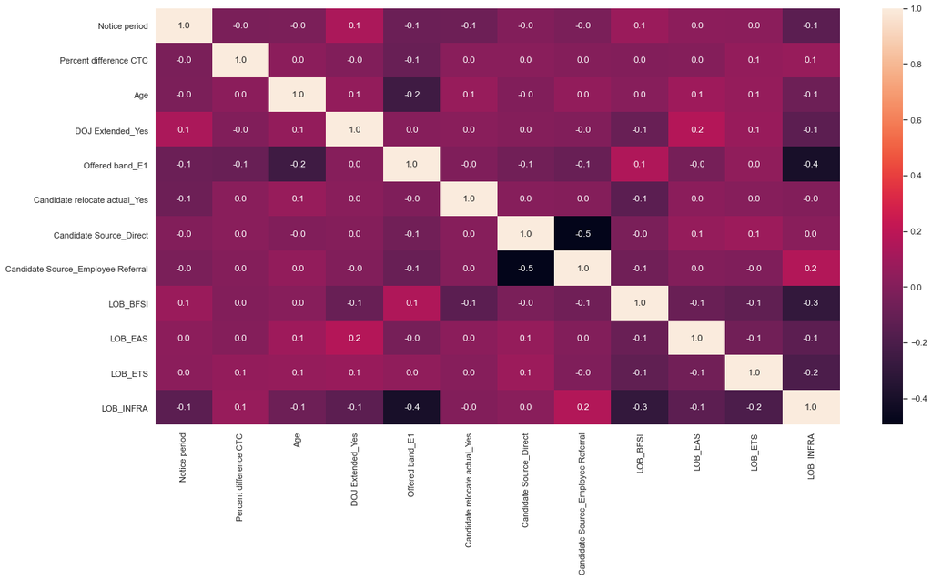

```python
plt.figure(figsize=(20,10))
sns.heatmap(encoded_data[significant_variables].corr(), annot = True, fmt ='.1f')
```

```python
log_reg = LogisticRegression(solver = 'lbfgs', max_iter=100)
```

```python
log_reg.fit(x_train, y_train)
```

```
LogisticRegression()
```

```python
y_pred = log_reg.predict(x_test)
y_pred[0:100]
```

```
array([1, 1, 1, 1, 1, 1, 1, 1, 1, 1, 1, 1, 1, 1, 1, 1, 1, 0, 1, 1, 1, 1,
       1, 1, 1, 1, 1, 1, 1, 1, 1, 1, 1, 1, 1, 1, 1, 0, 1, 1, 1, 1, 1, 1,
       1, 1, 1, 1, 1, 1, 1, 1, 0, 1, 1, 1, 1, 1, 1, 1, 1, 1, 1, 1, 1, 1,
       1, 1, 1, 1, 1, 1, 1, 1, 1, 1, 1, 1, 0, 1, 1, 1, 1, 1, 1, 1, 1, 1,
       1, 1, 1, 1, 1, 1, 1, 1, 1, 1, 1, 1], dtype=int64)
```

```python
log_reg.predict_proba(x_test)[0:28]
```

```
array([[0.17912268, 0.82087732],
       [0.25701682, 0.74298318],
       [0.14500599, 0.85499401],
       [0.07373053, 0.92626947],
       [0.1799012 , 0.8200988 ],
       [0.4898067 , 0.5101933 ],
       [0.22047997, 0.77952003],
       [0.00441254, 0.99558746],
       [0.00866192, 0.99133808],
       [0.22656172, 0.77343828],
       [0.17715002, 0.82284998],
       [0.3736419 , 0.6263581 ],
       [0.17914577, 0.82085423],
       [0.33445773, 0.66554227],
       [0.11397823, 0.88602177],
       [0.16522278, 0.83477722],
       [0.21535236, 0.78464764],
       [0.55119074, 0.44880926],
       [0.04919683, 0.95080317],
       [0.20235602, 0.79764398],
       [0.1808459 , 0.8191541 ],
       [0.40693989, 0.59306011],
       [0.41488107, 0.58511893],
       [0.1431762 , 0.8568238 ],
       [0.1608349 , 0.8391651 ],
       [0.34460682, 0.65539318],
       [0.18930066, 0.81069934],
       [0.30525284, 0.69474716]])
```

```python
log_reg.coef_[0:100]
```

```
array([[ 1.37398128e-01,  8.56441886e-04, -2.12814317e-02,
         7.64215385e-03, -2.26437716e-02,  3.53787364e-02,
         2.38391039e-01,  4.40196650e-01,  3.17767641e-01,
         2.20046791e-01, -1.78951077e-01,  3.69912344e+00,
        -1.36333382e-01,  2.93794818e-01,  8.14121759e-01,
         2.62543826e-01,  7.91579185e-02, -5.45428494e-01,
         1.90824027e-01,  4.77180086e-01,  7.32495651e-02,
         6.70198019e-01,  1.09933657e-01, -5.27977249e-02,
        -1.54224382e-01, -1.76378185e-02, -6.03971723e-02,
        -1.46110697e-01, -6.01807240e-02,  2.81945766e-01,
         2.36578898e-01,  5.89914173e-02,  7.73804570e-02]])
```

```python
def confusion_matrix(actuals,predicted):
    cm = metrics.confusion_matrix(actuals,predicted,[1,0])
    sns.heatmap(cm, annot = True, fmt ='.2f', xticklabels=['Joined', 'Not Joined'],
                yticklabels=['Joined', 'Not Joined'])

    plt.ylabel("Actual Labels")
    plt.xlabel("Predicted Labels")
```

```python
print(metrics.classification_report(y_test, log_reg.predict(x_test)))
```

```
              precision    recall  f1-score   support

           0       0.56      0.09      0.16       311
           1       0.83      0.98      0.90      1387

    accuracy                           0.82      1698
   macro avg       0.69      0.54      0.53      1698
weighted avg       0.78      0.82      0.76      1698
```

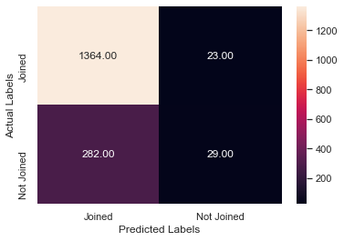

```python
confusion_matrix(y_test, y_pred)
```

### Decision Tree Classifier

```python
dtc = DecisionTreeClassifier()
```

```python
dtc.fit(x_train,y_train)
```

```
DecisionTreeClassifier()
```

```python
y_pred_dt = dtc.predict(x_test)
```

```python
y_pred_dt_train = dtc.predict(x_train)
```

```python
print(metrics.classification_report(y_test, y_pred_dt))
```

```
              precision    recall  f1-score   support

           0       0.30      0.35      0.32       311
           1       0.85      0.82      0.83      1387

    accuracy                           0.73      1698
   macro avg       0.57      0.58      0.58      1698
weighted avg       0.75      0.73      0.74      1698
```

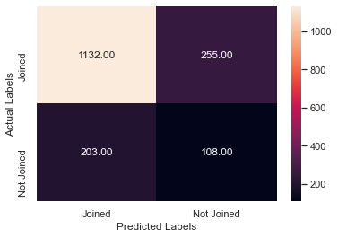

```python
confusion_matrix(y_test, y_pred_dt)
```

### KNeighbors Classifier

```python
knn_classifier = KNeighborsClassifier()
```

```python
knn_classifier.fit(x_train,y_train)
```

```
KNeighborsClassifier()
```

```python
y_pred_knn=knn_classifier.predict(x_test)
```

```python
print(classification_report(y_test, y_pred))
```

[output not shown]

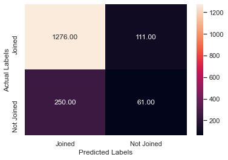

```python
confusion_matrix(y_test, y_pred_knn)
```

### Random Forest Regressor

```python
forest = RandomForestRegressor(n_estimators=10, random_state=17)
forest.fit(x_train, y_train)
```

```
RandomForestRegressor(n_estimators=10, random_state=17)
```

```python
y_train_pred = forest.predict(x_train)
y_test_pred = forest.predict(x_test)
print('Mean squared error (train): {:.3f}'.format(mean_squared_error(y_train, y_train_pred)))
print('Mean squared error (holdout): {:.3f}'.format(mean_squared_error(y_test, y_test_pred)))
```

```
Mean squared error (train): 0.029
Mean squared error (holdout): 0.151
```

```python
forest_params = {'max_depth': range(10, 25), 'max_features': range(6,12)}
locally_best_forest = GridSearchCV(forest, forest_params,scoring='neg_mean_squared_error', cv=5, n_jobs=-1)
locally_best_forest.fit(x_train, y_train)
print(abs(locally_best_forest.best_score_), locally_best_forest.best_params_)
```

```
0.1330381882012783 {'max_depth': 10, 'max_features': 9}
```

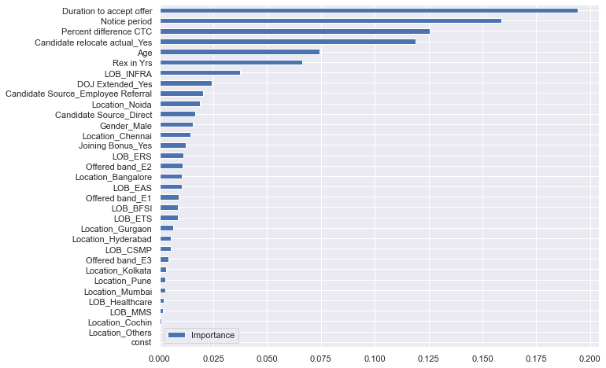

```python
importances = pd.DataFrame(locally_best_forest.best_estimator_.feature_importances_,index=x.columns,columns=['Importance'])
importances.sort_values('Importance').plot(kind='barh', figsize = (10,8));
```